# rsoccer_markdown

Akhila

01/05/2019

[output not shown]

[output not shown]

[output not shown]

[output not shown]

[output not shown]

[output not shown]

[output not shown]

[output not shown]

[output not shown]

# 1. The first leagues of Spain, England, Germany and Italy are considered the four most

# attractive football leagues in Europe.

# a. In which of the four leagues do on average score the most or the fewest goals

# per game

```r
    country <- country %>% rename(country_id=id)
    country_match <-merge(country,match,by=c("country_id"),all=TRUE)

   match_output1 <- country_match %>%
    group_by(league_id,match_api_id)%>%
       filter(str_detect(name, "Spain") | str_detect(name, "England") | str_detect(name, "Germany") | str_detect(name,              "Italy"))%>%
       select(league_id,match_api_id,home_team_goal,away_team_goal,name)%>%
       mutate(goal_score = home_team_goal+away_team_goal)%>%
    ungroup()%>%
      group_by(league_id,name)%>%
      summarise(average_score=mean(goal_score),sum=sum(goal_score),n=n())%>%
      arrange(desc(average_score))

   head(data.frame(match_output1))
```

```
##   league_id    name average_score  sum    n
## 1      7809 Germany      2.901552 7103 2448
## 2     21518   Spain      2.767105 8412 3040
## 3      1729 England      2.710526 8240 3040
## 4     10257   Italy      2.616838 7895 3017
```

# b. Compare the average, median, standard deviation, variance, range and

# interquartile distance of goals scored per match between the four most

# attractive European leagues and the remaining leagues.

```r
    match_output1 <- country_match %>%
     mutate(name =  ifelse(name %in% c("Spain","England","Germany","Italy") , "top league",
                                 "Others"))

   statistical_data_match <- match_output1 %>%
     group_by(league_id,match_api_id)%>%
     select(league_id,match_api_id,home_team_goal,away_team_goal,name)%>%
     mutate(goal_score = home_team_goal+away_team_goal)%>%
     ungroup()%>%
     group_by(name)%>%
     summarise(average_score=mean(goal_score),median(goal_score),
               sd(goal_score),var(goal_score),range=max(goal_score)-min(goal_score),
               IQR(goal_score),sum=sum(goal_score),n=n())

    statistical_data_match %>%
      select(1:9)
```

```
## # A tibble: 2 x 9
##   name  average_score `median(goal_sc~ `sd(goal_score)` `var(goal_score~
##   <chr>         <dbl>            <dbl>            <dbl>            <dbl>
## 1 Othe~          2.68                2             1.65             2.74
## 2 top ~          2.74                3             1.69             2.87
## # ... with 4 more variables: range <int>, `IQR(goal_score)` <dbl>,
## #   sum <int>, n <int>
```

# 2. Is there really a home advantage? Use a box plot to show the number of goals scored

# by home and away teams.

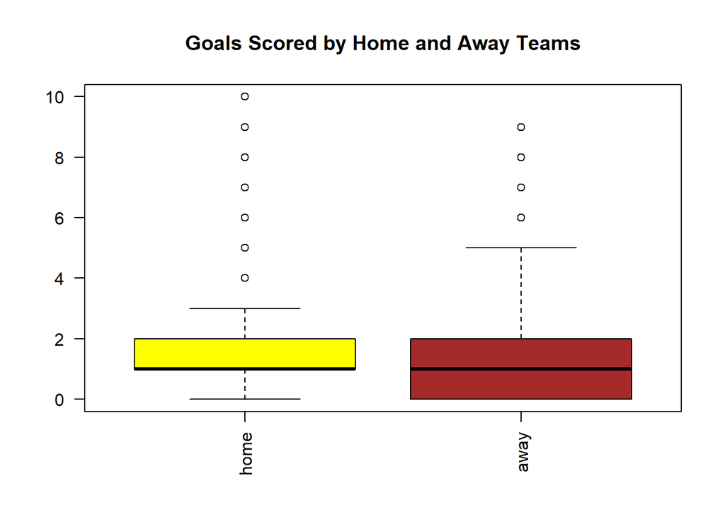

```r
goals_home_away <- match %>%
     summarise(home_team_goals = sum(home_team_goal),away_team_goals = sum(away_team_goal))

 home <- country_match$home_team_goal
   away <- country_match$away_team_goal
   boxplot(home,away,
           main = "Goals Scored by Home and Away Teams",
           at = c(1,2),
           names = c("home", "away"),
           las = 2,
           col = c("yellow","brown"),
           border = "black",
           vertical = FALSE,
           notch = FALSE)
```

# 3. “All soccer players are fair-weather players!” Check the assertion with a line chart: Do # on average more goals fall per game in the summer months than in the rest of the # year?

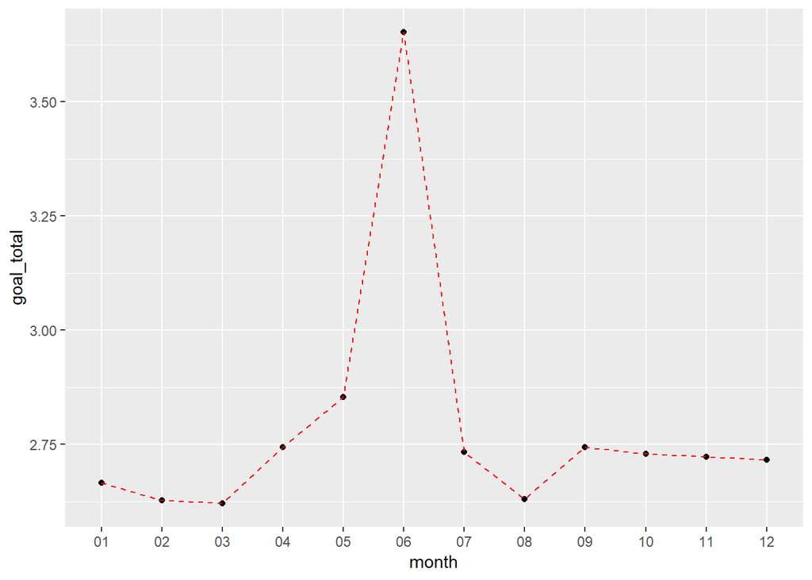

```r
match_addmonth <- match %>%
     select(date,match_api_id,home_team_goal,away_team_goal) %>%
     mutate(goal_total=home_team_goal+away_team_goal,month = date)

   match_addmonth$month <- format(as.Date(match_addmonth$month), "%m")

   ggploting <- ggplot(match_addmonth,aes(x=month, y=goal_total))
   ggploting+
     stat_summary(fun.y=mean,geom="point")+
     stat_summary(fun.y=mean,geom="line",aes(group=1),color="red",linetype="dashed")
```

```r
   #match_addmonth <- match_addmonth %>%
   # mutate(seasondiff =  ifelse(month %in% c("06","07","08") , "Summer",
   #                              ifelse(month %in% c("01","02","03","04","05"), "Others","Others")))
   #attach(match_addmonth)
   #plotmeans(goal_total ~ seasondiff, data = match_addmonth)
```

# 4. Display the average goals scored per game for the top 4 leagues per year from 2008

# to 2016

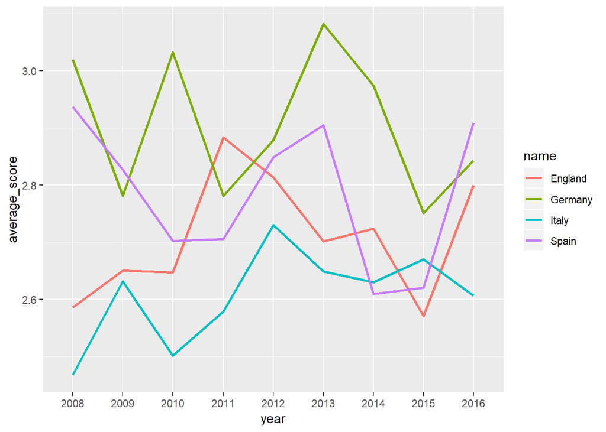

```r
  match_addyear <- country_match %>%
    select(league_id,name,match_api_id,date,home_team_goal,away_team_goal) %>%
    mutate(goal_total=home_team_goal+away_team_goal,year = date)

  match_addyear$year <- format(as.Date( match_addyear$year), "%Y")

  match_byyear <- match_addyear %>%
    group_by(league_id,match_api_id)%>%
    filter(str_detect(name, "Spain")|str_detect(name,"England")|str_detect(name,"Germany")|str_detect(name,"Italy"))%>%
    select(league_id,match_api_id,home_team_goal,away_team_goal,name,date,year)%>%
    mutate(goal_score = home_team_goal+away_team_goal)%>%
    ungroup()%>%
    group_by(name,year)%>%
    summarise(average_score=mean(goal_score),sum=sum(goal_score),n=n())%>%
    arrange(desc(average_score))

  ggplot(match_byyear, aes(x=year, y=average_score,group=name, color=name)) + geom_line(size=1)
```

# 5. Use an estimated density function curve AND a QQ-plot to check whether the # home_team_possession variable is (approximately) normally distributed.

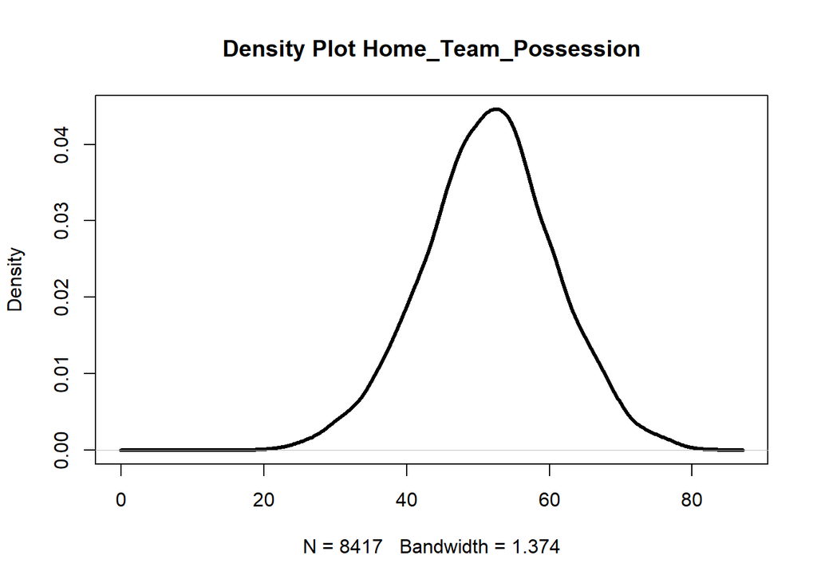

```r
  plot(density(na.omit(match$home_team_possession)),main ="Density Plot Home_Team_Possession",lwd =3 )
```

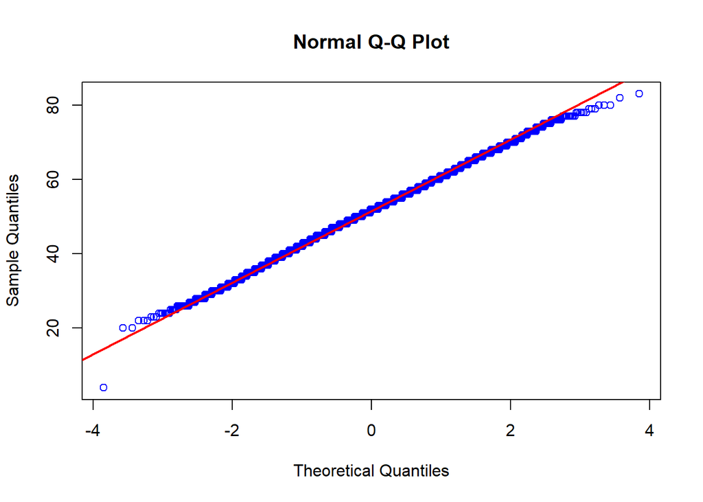

```r
  {qqnorm(match$home_team_possession,col ="blue")
  qqline(match$home_team_possession,col ="red",lwd =2)}

  #log to get closer to the line to see the distribution clearly
  log.home_team_possession <-match$home_team_possession
  {qqnorm(log.home_team_possession,col ="blue")
  qqline(match$home_team_possession,col ="red",lwd =2)}
```

[output not shown]

# 6. Use a box plot to show whether there is a correlation between ball ownership # (home_team_possession) and the number of goals (home_team_goals) scored per # game for home teams. Create four categories of ball ownership shares: very low # (≤25%), low (25% < x ≤50%), high (50% < x ≤75%), and very high (x > 75%).

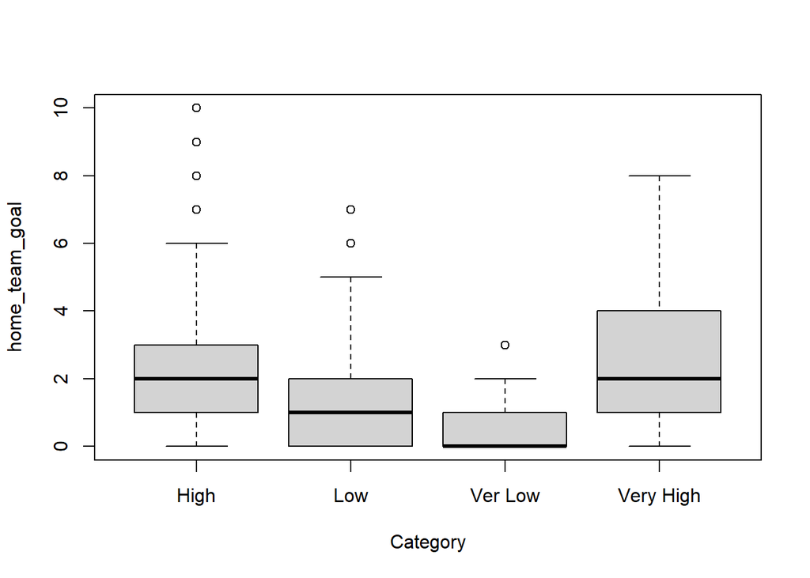

```r
 match_corr <- match %>%
      select(home_team_possession,home_team_goal)
  match_corr <- subset(match_corr, home_team_possession != "NA")

  match_corr$home_team_possession <- as.numeric(match_corr$home_team_possession)

  match_corr <- match_corr %>%
    mutate(category =  ifelse(home_team_possession %in% c(0:25) , "Ver Low",
                                ifelse(home_team_possession %in% c(26:50), "Low",
                                       ifelse(home_team_possession %in% c(51:75), "High","Very High"))))
  attach(match_corr)
  boxplot(home_team_goal~factor(category),xlab = "Category", data = match_corr, col = "lightgray")
```